# GED16/AO808: Análise de Regressão

AULA04: Prática

Professora: Denise B. Ferrari

1o. semestre/2021

### Introdução

“[Infecção hospitalar](https://www.prefeitura.sp.gov.br/cidade/secretarias/saude/vigilancia_em_saude/infeccao_hospitalar/index.php?p=6445) é uma infecção adquirida após a admissão do paciente na unidade hospitalar e pode se manifestar durante a internação ou após a alta. Pela sua gravidade e aumento do tempo de internação do paciente, é causa importante de morbidade e mortalidade, caracterizando-se como problema de saúde pública.”

Os dados disponíveis no arquivo `data/SCENIC.txt` foram coletados pelo CDC (US Center for Disease Control), no âmbito do [Projeto SCENIC](https://doi.org/10.1093/oxfordjournals.aje.a112928). O principal objetivo do projeto era determinar se programas de vigilância e controle foram capazes de reduzir as taxas de infecção hospitalar. Os dados referem-se a uma amostra de 113 hospitais selecionados a partir de um conjunto de 338 hospitais avaliados. Cada linha do conjunto de dados contém uma identificação (1-113) e fornece informação a respeito de 11 variáveis para um único hospital. Os dados apresentados referem-se ao período de 1975-1976.

As 12 variáveis são:

1. `IDnumber`: 1-113 (identificação do hospital)
2. `LengthStay`: período de internação médio de todos os pacientes no hospital (em dias)
3. `Age`: idade média dos pacientes (anos)
4. `InfectRisk`: risco de infecção, calculado como a probabilidade média estimada de contrair infecção no hospital (em %)
5. `CultRatio`: razão do número de culturas realizadas pelo número de pacientes sem sintomas de infecção hospitalar, vezes 100
6. `XrayRatio`: razão do número de raios-X realizados pelo número de pacientes sem sintomas de pneumonia, vezes 100
7. `NBeds`: número médio de leitos do hospital, durante o período avaliado
8. `MedSchool`: afiliação a alguma Escola de Medicina (1=Sim, 2=Não)
9. `Region`: região geográfica (1=NE, 2=NC, 3=S, 4=W)
10. `DailyCensus`: número médio de pacientes no hospital por dia, durante o período avaliado
11. `NNurses`: número médio de enfermeiros no hospital
12. `Facilities`: percentual de 35 serviços providos pelo hospital

Acredita-se que o período médio de internação de um paciente `LengthStay` (variável de resposta) possa ser previsto a partir do risco de infecção hospitalar, bem como outras características do hospital e de procedimentos de rotina realizados.

### Análise Exploratória de Dados

Conduza a análise exploratória da massa de dados `SCENIC`, a fim de compreender suas características principais.

```r
rm(list=ls())
scenic <- read.table("data/SCENIC.txt", header = FALSE)
```

### PARTE 1: Regressão Linear Simples

1. Assuma que um modelo de regressão linear simples é adequado para modelar a relação da variável de resposta `LengthStay` a cada uma das variáveis explicativas `InfectRisk`, `Facilities` e `XrayRatio`.
- Construa um modelo de regressão para cada um desses pares de variáveis;
- Construa gráficos de dispersão (separados) com as retas de regressão ajustadas para cada caso;
- Calcule o MSE para cada modelo. Que variável explicativa produz menor variabilidade em torno da reta de regressão ajustada?
- Utilizando R<sup>2</sup> como critério, qual das variáveis explicativas contribui para a maior redução na variabilidade da resposta `LengthStay`?
2. Para cada região geográfica, construa um modelo de regressão para a variável de resposta `LengthStay` em função de `InfectRisk`. Assuma que o modelo de 1a. ordem é adquado para modelar essas relações. Obtenha os modelos de regressão ajustados.
- As funções de regressão estimadas são semelhantes para as quatro regiões? Discuta.
- Calcule o MSE para cada região. A variabilidade em torno da reta de regressão ajustada é semelhante para as quatro regiões?
- Construa intervalos de confiança 95% para o coeficiente angular da reta de regressão para cada região. As retas de regressão para diferentes regiões parecem ter mesma inclinação? O que se pode concluir?
- Construa intervalos de confiança para a resposta esperada correspondendo a `InfectRisk = 5`, para cada região. O que se pode concluir?
- Construa intervalos de previsão para um novo hospital em cada região que tenha `InfectRisk = 5`. O que se pode concluir?

### Diagnóstico

1. Para cada um dos três modelos de regressão ajustados no item (1) da seção anterior, realize o diagnóstico através da análise dos resíduos e apresente um resumo de suas conclusões. O modelo de regressão linear simples clássico é adequado a alguma das situações investigadas?
2. Ajuste um modelo de regressão linear simples para a variável `LengthStay` como função de `InfectRisk` após excluir as observações 47 (X = 6.5 e Y = 19.56) e 112 (X = 5.9 e Y = 17.94). Obtenha intervalos de previsão de 95% de confiança para novas observações que apresentam valores da variável explicativa iguais a 6.5 e 5.9. As observações eliminadas encontram-se nos limites dos intervalos de previsão obtidos? Discuta o significado dos resultados obtidos.
3. Para os modelos considerando cada região geográfica separadamente no item (2) da seção anterior, realize o diagnóstico através da análise dos resíduos. Todas as regiões aparentam ter mesma variância dos erros? Que conclusões é possível obter a partir da análise?

### PARTE 2: Regressão Linear Múltipla

Dois modelos foram propostos para prever o período médio de internação de um paciente (`LengthStay`):

**Modelo I**: utiliza como variáveis explicativas `Age`, `InfectRisk` e `Facilities`

**Modelo II**: utiliza como variáveis explicativas `NBeds`, `InfectRisk` e `Facilities`

1. Construa a matriz de gráficos de dispersão, bem como a matriz de correlação para cada modelo proposto. Interprete os resultados obtidos.
2. Para cada modelo, ajuste um modelo de regressão de 1a. ordem com as três variáveis explicativas consideradas. Discuta os resultados obtidos.
3. Realize o diagnóstico dos modelos. É possível identificar um modelo que seja mais adequado aos dados?
4. Para cada região geográfica, construa um modelo de regressão de 1a. ordem para `InfectRisk` como função das variáveis `Age`, `CultRatio`, `DailyCensus` e `Facilities`.
   - Comente sobre os resultados obtidos para os modelos ajustados.
   - As funções de regressão estimadas são semelhantes nas quatro regiões? Discuta.
   - Analise os valores de MSE e $R^2_aj$ para cada modelo Essas medidas são semelhantes para as quatro regiões? Discuta.
   - Realize o diagnóstico dos modelos construídos. Interprete os gráficos e os resultados obtidos.

### Análise de Somas de Quadrados Extras

Decidiu-se prever o período médio de internação de um paciente (`LengthStay`), em função das variáveis `Age` e `InfectRisk`. A questão agora é se a inclusão de outra variável explicativa adicional no modelo seria útil e, em caso positivo, qual delas seria mais útil. Foram consideradas as seguintes variáveis extras: `CultRatio`, `DailyCensus`, `NNurses` e `Facilities`.

Assuma que um modelo de regressão linear múltipla de 1a. ordem é adequado.

1. Analise as somas de quadrados extras e discuta qual das quatro variáveis explicativas candidatas é a melhor inclusão.
2. Conduza um teste utilizando a estatística F parcial (com nível de significância 5%) para decidir se a variável escolhida no item anterior é útil no modelo de regressão que já contém `Age` e `InfectRisk`. Descreva as alternativas, a regra de decisão e a conclusão do teste. A estatística F parcial correspondente para as outras três candidatas teria valor tão elevado quando a da variável escolhida? Discuta.

### Multicolinearidade

Um modelo de regressão de 1a. ordem para `LengthStay` em função de `Age`, `XrayRatio`, `DailyCensus` é construído com base nas observações 57-113. Com base na matriz de gráficos de dispersão, matriz de correlação e VIFs, analise se há indícios de problemas sérios de multicolinearidade. Justifique sua análise.

### Modelo 1:

#### 1.

```r
rm(list = ls())


scenic <- read.table("data/SCENIC.txt")
colnames(scenic) <- c("IDnumber","LengthStay","Age","InfectRisk","CultRatio","XrayRatio","NBeds","MedSchool","Region","DailyCensus","NNurses","Facilities")

attach(scenic)
summary(scenic)
```

```
##     IDnumber     LengthStay          Age          InfectRisk      CultRatio
##  Min.   :  1   Min.   : 6.700   Min.   :38.80   Min.   :1.300   Min.   : 1.60
##  1st Qu.: 29   1st Qu.: 8.340   1st Qu.:50.90   1st Qu.:3.700   1st Qu.: 8.40
##  Median : 57   Median : 9.420   Median :53.20   Median :4.400   Median :14.10
##  Mean   : 57   Mean   : 9.648   Mean   :53.23   Mean   :4.355   Mean   :15.79
##  3rd Qu.: 85   3rd Qu.:10.470   3rd Qu.:56.20   3rd Qu.:5.200   3rd Qu.:20.30
##  Max.   :113   Max.   :19.560   Max.   :65.90   Max.   :7.800   Max.   :60.50
##    XrayRatio          NBeds         MedSchool        Region
##  Min.   : 39.60   Min.   : 29.0   Min.   :1.00   Min.   :1.000
##  1st Qu.: 69.50   1st Qu.:106.0   1st Qu.:2.00   1st Qu.:2.000
##  Median : 82.30   Median :186.0   Median :2.00   Median :2.000
##  Mean   : 81.63   Mean   :252.2   Mean   :1.85   Mean   :2.363
##  3rd Qu.: 94.10   3rd Qu.:312.0   3rd Qu.:2.00   3rd Qu.:3.000
##  Max.   :133.50   Max.   :835.0   Max.   :2.00   Max.   :4.000
##   DailyCensus       NNurses        Facilities
##  Min.   : 20.0   Min.   : 14.0   Min.   : 5.70
##  1st Qu.: 68.0   1st Qu.: 66.0   1st Qu.:31.40
##  Median :143.0   Median :132.0   Median :42.90
##  Mean   :191.4   Mean   :173.2   Mean   :43.16
##  3rd Qu.:252.0   3rd Qu.:218.0   3rd Qu.:54.30
##  Max.   :791.0   Max.   :656.0   Max.   :80.00
```

```r
data_model1 <- data.frame(Age = Age, Facilities = Facilities, InfectRisk = InfectRisk, LengthStay = LengthStay)


cor(data_model1)
```

```
##                     Age  Facilities  InfectRisk LengthStay
## Age         1.000000000 -0.04045138 0.001093166  0.1889140
## Facilities -0.040451379  1.00000000 0.412600675  0.3555379
## InfectRisk  0.001093166  0.41260068 1.000000000  0.5334438
## LengthStay  0.188913972  0.35553792 0.533443831  1.0000000
```

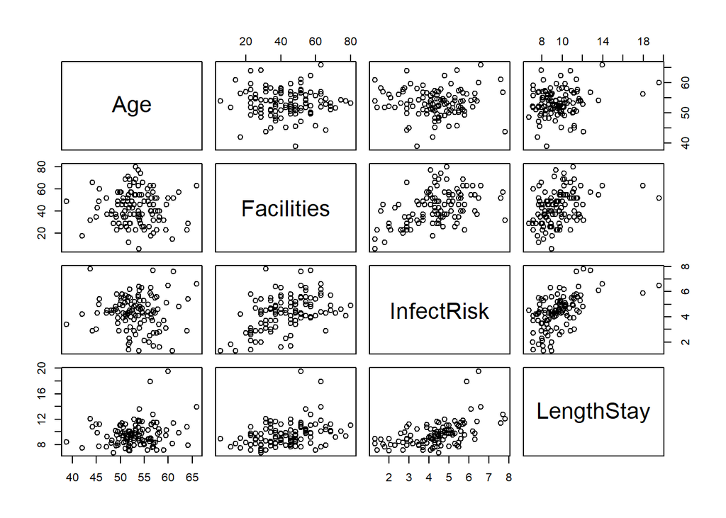

```r
plot(data_model1)
```

Visualmente, há uma sugestão de correlação linear entre LengthStay e InfectRisk, bem como com Facilities também. Já podemos mapear um possivel problema futuro, ao observarmos uma possível relação linear entre Facilities e InfectRisk.

Analisando a matriz de correlação percebemos um coeficiente baixo para Age e LengthStay frente aos demais,todavia, para efeito de modelo dentro do problema proposto, já podemos continuar com a hipotese inicial.

#### 2. Ajuste do Modelo

```r
rlm.m1 <- lm(LengthStay ~  Age + InfectRisk + Facilities, data = data_model1)
rlm.m1
```

```
##
## Call:
## lm(formula = LengthStay ~ Age + InfectRisk + Facilities, data = data_model1)
##
## Coefficients:
## (Intercept)          Age   InfectRisk   Facilities
##     1.38646      0.08371      0.65845      0.02174
```

```r
summary(rlm.m1)
```

```
##
## Call:
## lm(formula = LengthStay ~ Age + InfectRisk + Facilities, data = data_model1)
##
## Residuals:
##     Min      1Q  Median      3Q     Max
## -2.9998 -0.8594 -0.1823  0.7109  7.7619
##
## Coefficients:
##             Estimate Std. Error t value Pr(>|t|)
## (Intercept)  1.38646    1.86622   0.743   0.4591
## Age          0.08371    0.03325   2.518   0.0133 *
## InfectRisk   0.65845    0.12135   5.426 3.52e-07 ***
## Facilities   0.02174    0.01071   2.029   0.0449 *
## ---
## Signif. codes:  0 '***' 0.001 '**' 0.01 '*' 0.05 '.' 0.1 ' ' 1
##
## Residual standard error: 1.568 on 109 degrees of freedom
## Multiple R-squared:  0.3448, Adjusted R-squared:  0.3267
## F-statistic: 19.12 on 3 and 109 DF,  p-value: 4.931e-10
```

A análise indica que os coeficientes são estatisticamente diferentes de zero, com exceção do Incercept, porém o valor nulo para as variáveis explicativas não se encontra dentro da nossa base de dados, logo, indicam que existe uma associação estatisticamente linear entre a variável de resposta e as variáveis explicativas.

Ao incluir as três variáveis do modelo, observamos que a variação total de LengthStay se reduz em cerca de 35% o que indica que o modelo não explica tão bem o fenômeno apenas com essas variáveis. Como R2, R2adj indicam valores semelhantes, não há overfiting aparente, contudo o valor baixo de ambos sugere que o modelo não engloba as todas as variáveis necessárias.

#### 3. Diagnóstico

Analisaremos se há padrão sistemático nos resíduos do modelo 1:

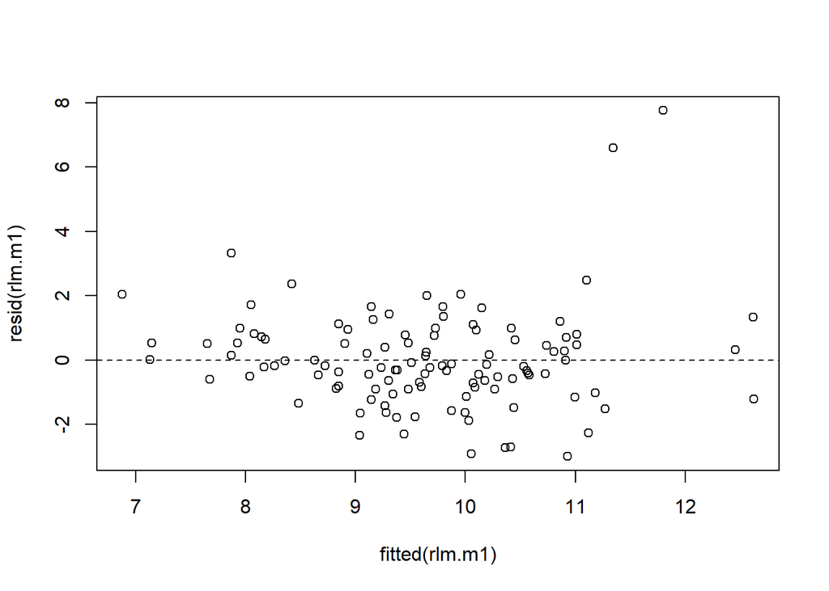

```r
# Grafico: resid x resposta ajustada (yhat)
plot(fitted(rlm.m1), resid(rlm.m1))
abline(h=0, lty="dashed")
```

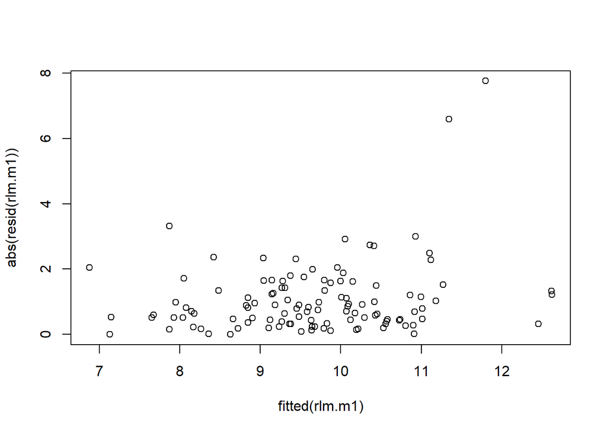

```r
# Grafico: |resid| x resposta ajustada (yhat)
plot(fitted(rlm.m1), abs(resid(rlm.m1)))
```

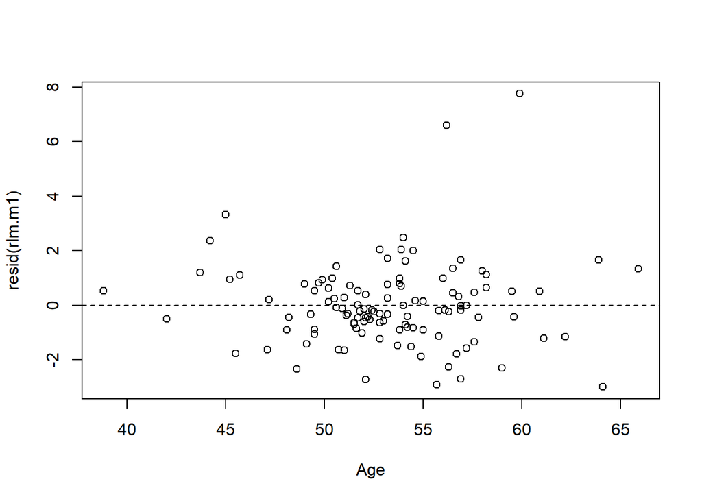

```r
# Grafico: resid x var. explic. Age
plot(Age, resid(rlm.m1))
abline(h=0, lty="dashed")
```

Estes gráficos não revelam nenhum desvio sistemático da resposta linear. A variância dos erros permanece aproximadamente constante para todos os valores de resposta ajustada.

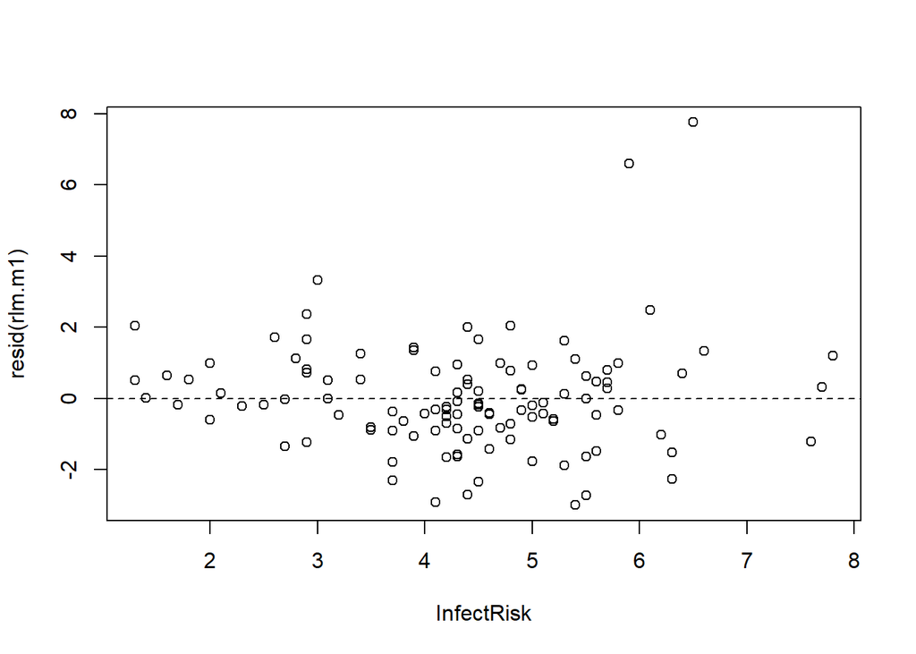

```r
# Grafico: resid x var. explic. InfectRisk
plot(InfectRisk, resid(rlm.m1))
abline(h=0, lty="dashed")
```

Este gráfico não revela nenhum desvio sistemático da resposta linear. A variância dos erros permanece aproximadamente constante para todos os valores de resposta ajustada.

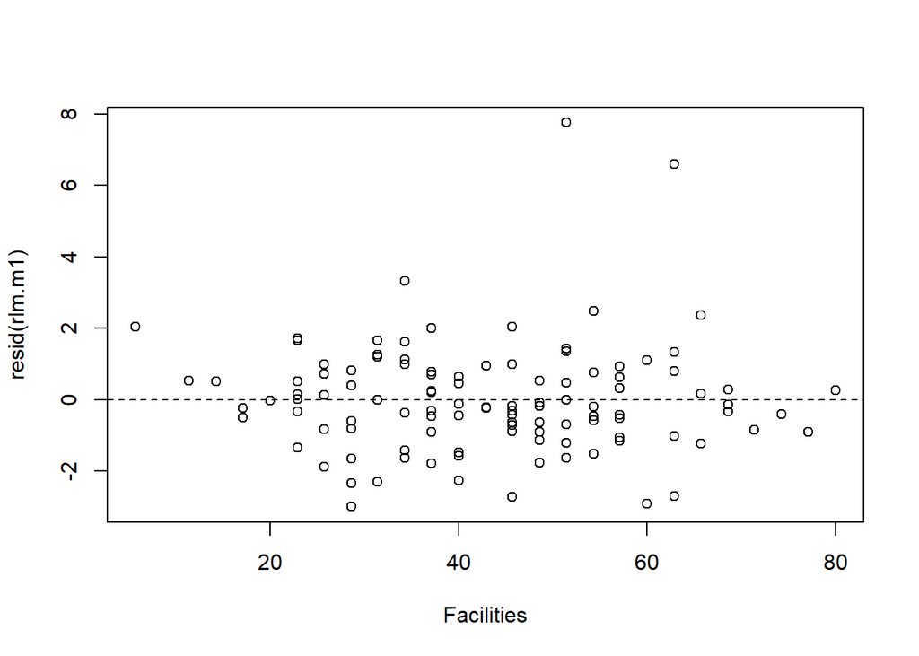

```r
# Grafico: resid x var. explic. Facilities
plot(Facilities, resid(rlm.m1))
abline(h=0, lty="dashed")
```

Este gráfico não revela nenhum desvio sistemático da resposta linear. A variância dos erros permanece aproximadamente constante para todos os valores de resposta ajustada.

Assim, vamos avaliar a possibilidade de existirem efeitos de interação entre as var. explicativas, que possam ter sido omitidos do modelo:

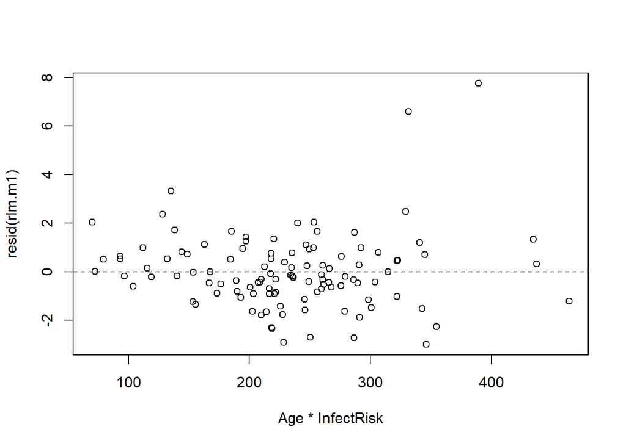

```r
# Grafico comparando Age e InfectRisk
plot(Age*InfectRisk, resid(rlm.m1))
abline(h=0, lty="dashed")
```

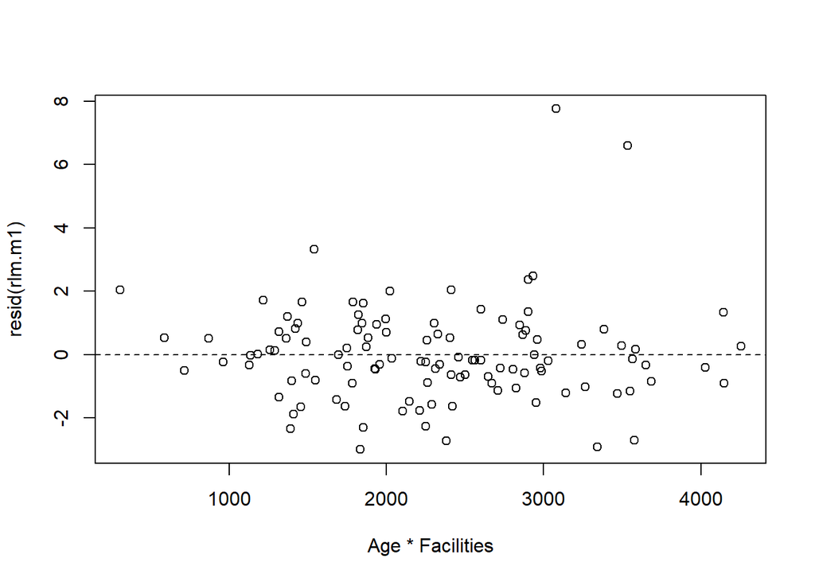

```r
# Grafico comparando Age e Facilities
plot(Age*Facilities, resid(rlm.m1))
abline(h=0, lty="dashed")
```

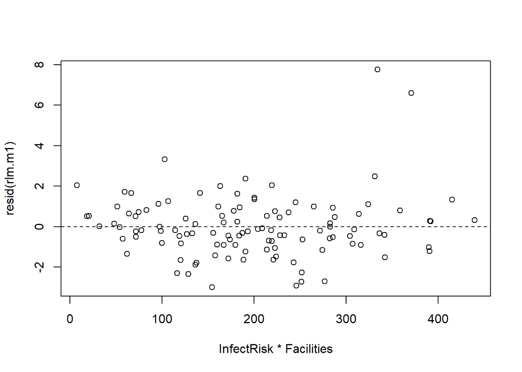

```r
# Grafico comparando InfectRisk e Facilities
plot(InfectRisk*Facilities, resid(rlm.m1))
abline(h=0, lty="dashed")
```

Não podemos perceber nenhum padrão sistemático nos gráficos. Se este fosse o caso, sugeriria a presença de efeitos de interação, de forma que um modelo do tipo

E[Y] = beta0 + beta1 * X1 + beta2 * X2 + beta3 * X3 + beta4 * X3 * X2 + beta5 * X3 * X1 + beta6 * X1 * X2

poderia ser mais adequado.

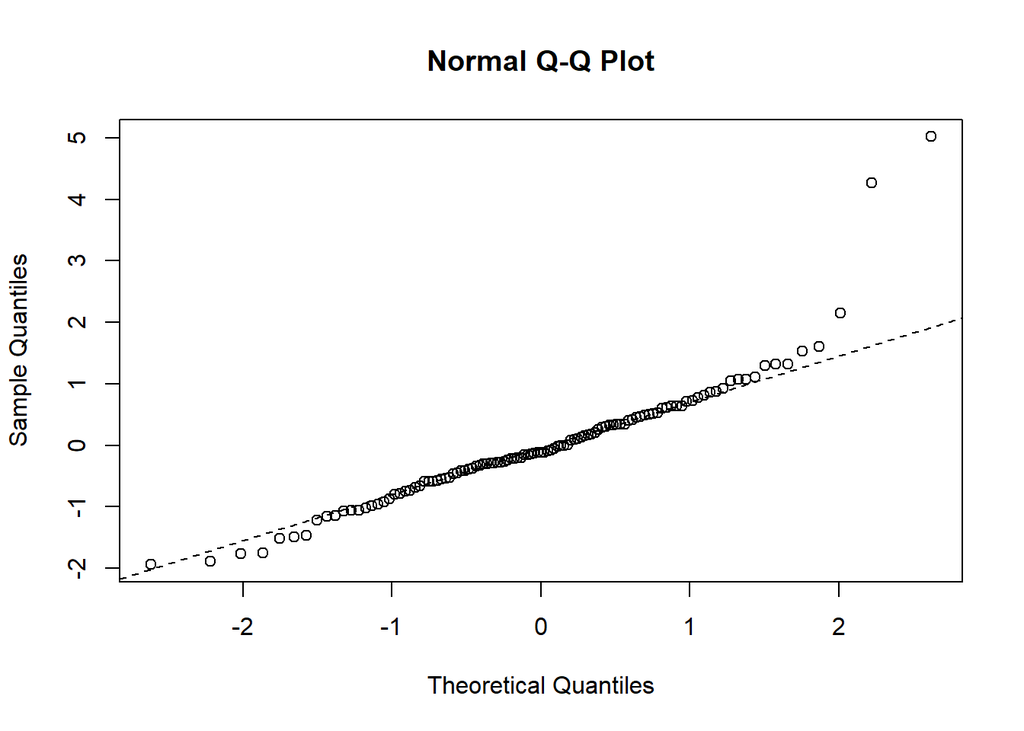

```r
# Grafico de probabilidade (ou de quantis) para os resíduos padronizados
resid.std <- (resid(rlm.m1))/sd(resid(rlm.m1))
qqnorm(resid.std)
qqline(resid.std, lty="dashed") # adiciona reta que passa pelo 1o. e 3o. quartis
```

O gráfico de quantis não indica desvios importantes da normalidade, porém apresenta apenas 3 possíveis outliers. Neste caso, não faz sentido gerar graficos temporais, já que os dados foram obtidos em “cross-section”.

### Modelo 2

#### 1.

```r
data_model2 <- data.frame(NBeds = NBeds, Facilities = Facilities, InfectRisk = InfectRisk, LengthStay = LengthStay)
cor(data_model2)
```

```
##                NBeds Facilities InfectRisk LengthStay
## NBeds      1.0000000  0.7945244  0.3597700  0.4092652
## Facilities 0.7945244  1.0000000  0.4126007  0.3555379
## InfectRisk 0.3597700  0.4126007  1.0000000  0.5334438
## LengthStay 0.4092652  0.3555379  0.5334438  1.0000000
```

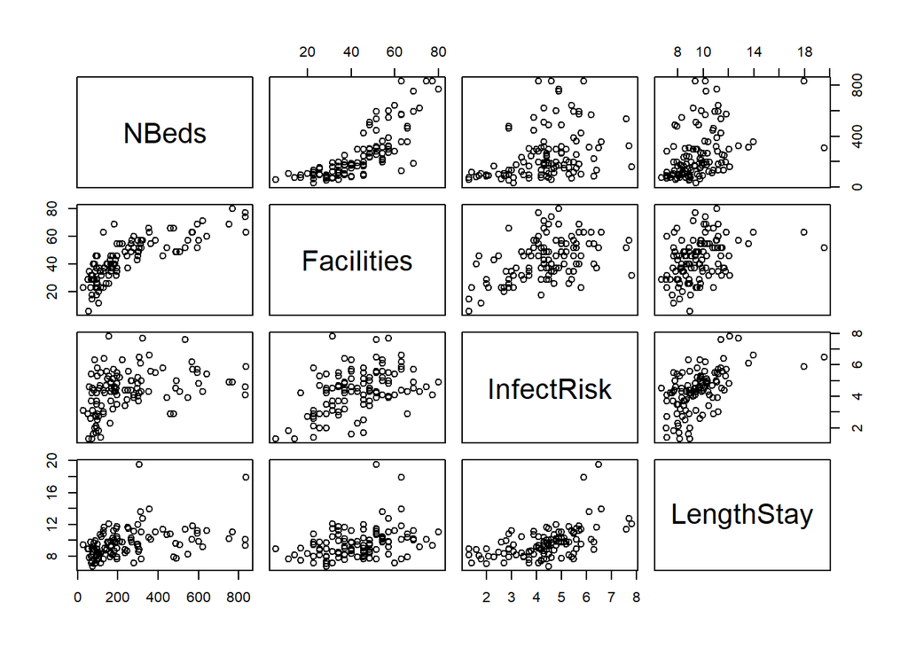

```r
plot(data_model2)
```

Visualmente, há uma sugestão de correlação linear entre LengthStay e InfectRisk, bem como com Facilities também. Já podemos mapear um possivel problema futuro, ao observarmos uma possível relação linear entre Facilities e InfectRisk.

Analisando a matriz de correlação percebemos temos coeficientes baixos para as três variáveis(por volta de 0.4),apesar de não serem tão elevados quanto gostaríamos, iremos prosseguir com o modelo.

#### 2. Ajuste de Modelo

```r
rlm.m2 <- lm(LengthStay ~  NBeds + InfectRisk + Facilities, data = data_model2)
rlm.m2
```

```
##
## Call:
## lm(formula = LengthStay ~ NBeds + InfectRisk + Facilities, data = data_model2)
##
## Coefficients:
## (Intercept)        NBeds   InfectRisk   Facilities
##    6.467380     0.003018     0.647707    -0.009285
```

```r
summary(rlm.m2)
```

```
##
## Call:
## lm(formula = LengthStay ~ NBeds + InfectRisk + Facilities, data = data_model2)
##
## Residuals:
##     Min      1Q  Median      3Q     Max
## -2.9504 -0.9707 -0.1877  0.7496  8.4363
##
## Coefficients:
##              Estimate Std. Error t value Pr(>|t|)
## (Intercept)  6.467380   0.615157  10.513  < 2e-16 ***
## NBeds        0.003018   0.001272   2.373   0.0194 *
## InfectRisk   0.647707   0.121908   5.313 5.76e-07 ***
## Facilities  -0.009285   0.016524  -0.562   0.5753
## ---
## Signif. codes:  0 '***' 0.001 '**' 0.01 '*' 0.05 '.' 0.1 ' ' 1
##
## Residual standard error: 1.573 on 109 degrees of freedom
## Multiple R-squared:  0.3407, Adjusted R-squared:  0.3226
## F-statistic: 18.78 on 3 and 109 DF,  p-value: 6.854e-10
```

A estatística F do modelo sugere que pelo menos uma das variáveis é significativa para o modelo empregado. As estatísticas para cada coeficiente indicam que apenas a variável Facilities não aparenta ser significativa no modelo empregado. Como os valores de R2 e R2 ajustado estão próximos, não há variáveis em excesso no modelo contudo os valores baixos para ambos esses coeficientes indicam que as variáveis propostas não capturam completamente a variação da variável de resposta.

#### 3. Diagnóstico

Analisaremos se há padrão sistemático nos resíduos para os 2 modelos:

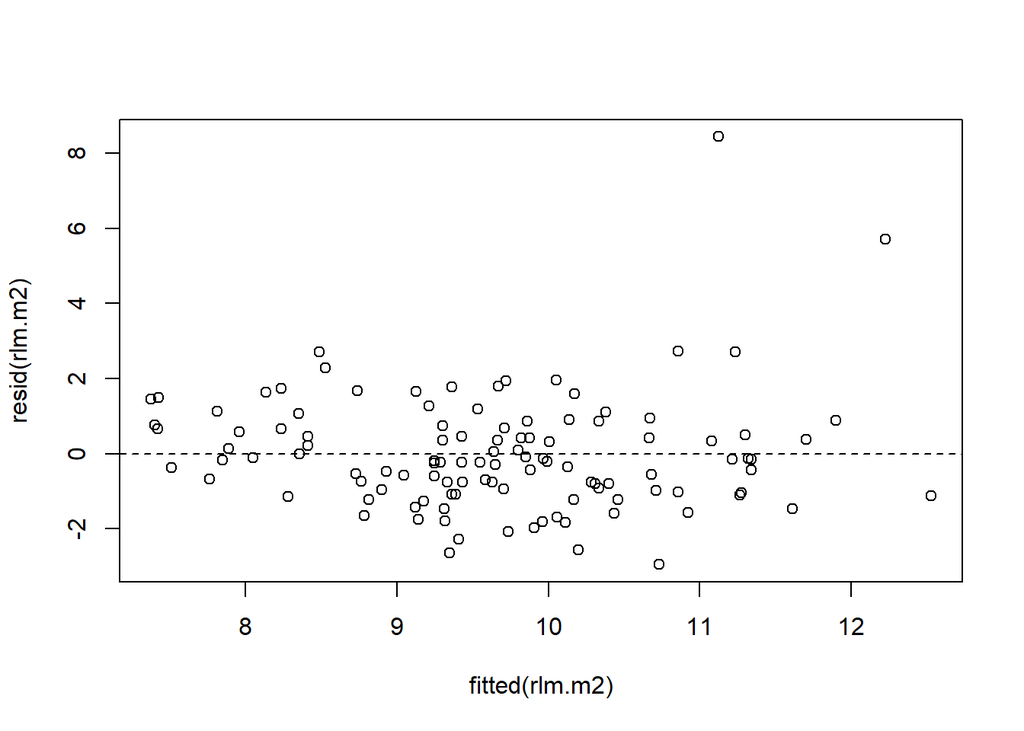

```r
# Grafico: resid x resposta ajustada (yhat)
plot(fitted(rlm.m2), resid(rlm.m2))
abline(h=0, lty="dashed")
```

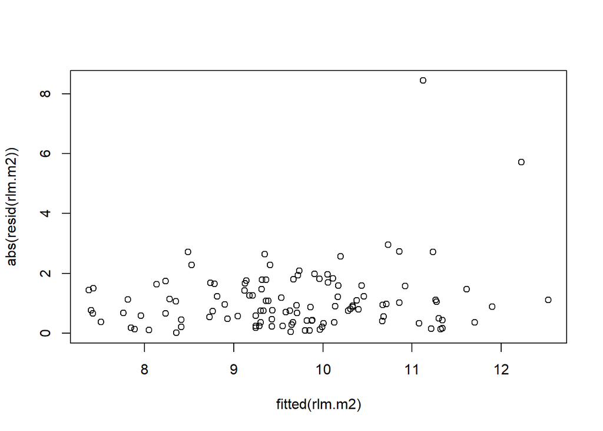

```r
# Grafico: |resid| x resposta ajustada (yhat)
plot(fitted(rlm.m2), abs(resid(rlm.m2)))
```

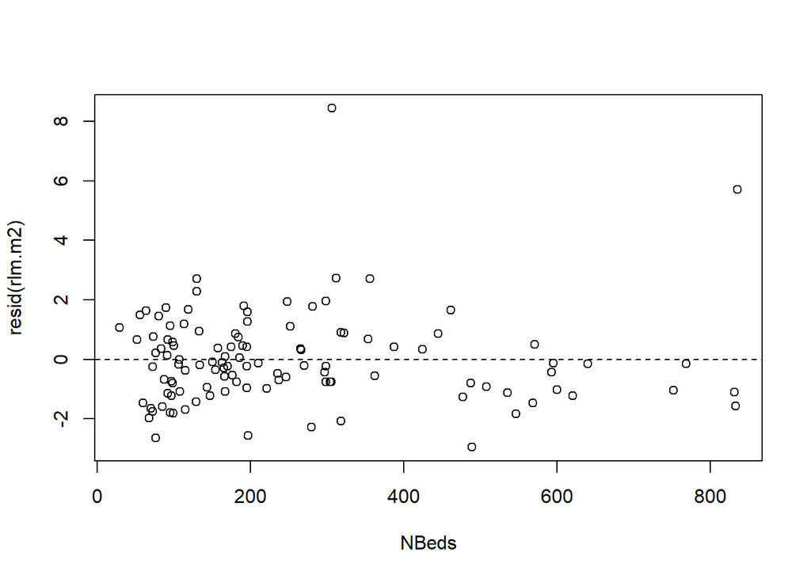

```r
# Grafico: resid x var. explic. NBeds
plot(NBeds, resid(rlm.m2))
abline(h=0, lty="dashed")
```

Estes gráficos não revelam nenhum desvio sistemático da resposta linear. A variância dos erros permanece aproximadamente constante para todos os valores de resposta ajustada.

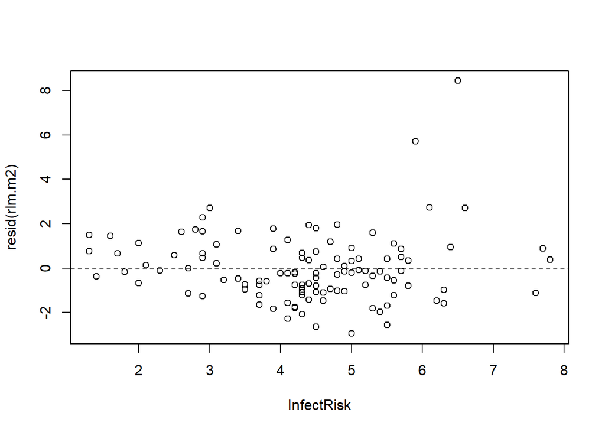

```r
# Grafico: resid x var. explic. InfectRisk
plot(InfectRisk, resid(rlm.m2))
abline(h=0, lty="dashed")
```

Estes gráficos não revelam nenhum desvio sistemático da resposta linear. A variância dos erros permanece aproximadamente constante para todos os valores de resposta ajustada.

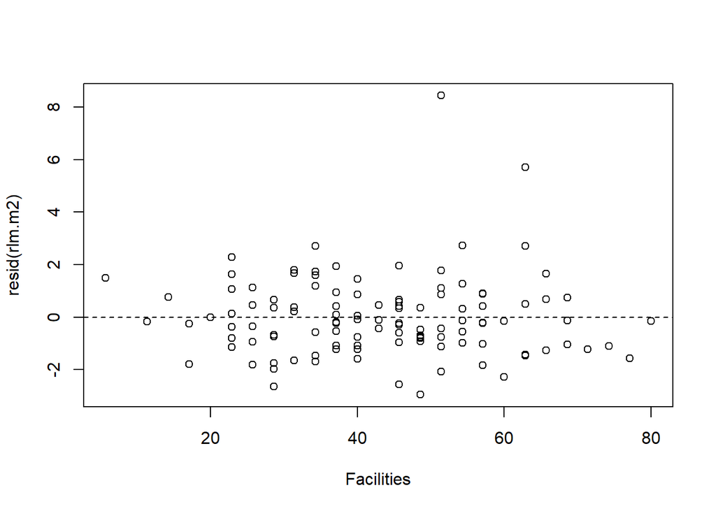

```r
# Grafico: resid x var. explic. Facilities
plot(Facilities, resid(rlm.m2))
abline(h=0, lty="dashed")
```

Estes gráficos não revelam nenhum desvio sistemático da resposta linear. A variância dos erros permanece aproximadamente constante para todos os valores de resposta ajustada.

Assim, vamos avaliar a possibilidade de existirem efeitos de interação entre as var. explicativas, que possam ter sido omitidos do modelo:

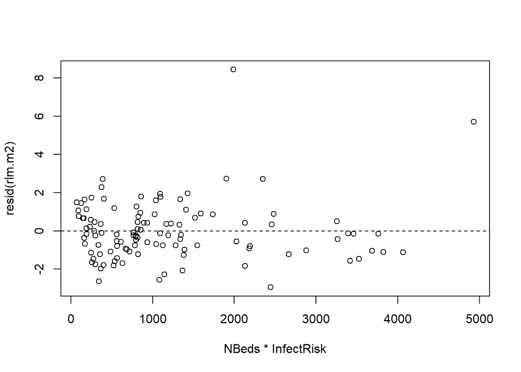

```r
# Grafico comparando NBeds e InfectRisk
plot(NBeds*InfectRisk, resid(rlm.m2))
abline(h=0, lty="dashed")
```

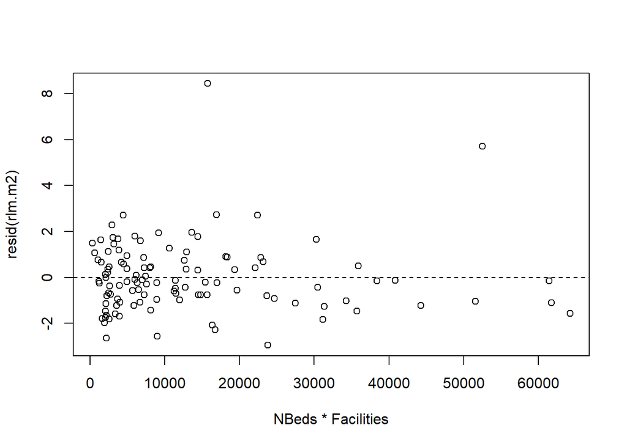

```r
# Grafico comparando NBeds e Facilities
plot(NBeds*Facilities, resid(rlm.m2))
abline(h=0, lty="dashed")
```

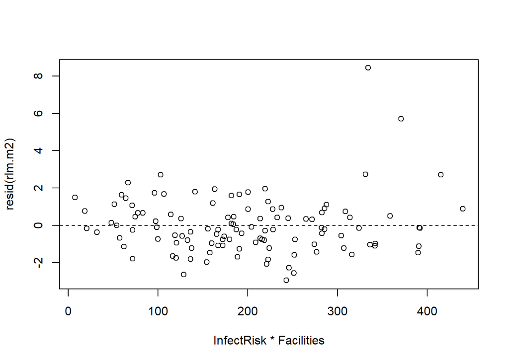

```r
# Grafico comparando InfectRisk e Facilities
plot(InfectRisk*Facilities, resid(rlm.m2))
abline(h=0, lty="dashed")
```

Não podemos perceber nenhum padrão sistemático nos gráficos. Se este fosse o caso, sugeriria a presença de efeitos de interação, de forma que um modelo do tipo

E[Y] = beta0 + beta1 * X1 + beta2 * X2 + beta3 * X3 + beta4 * X3 * X2 + beta5 * X3 * X1 + beta6 * X1 * X2

poderia ser mais adequado.

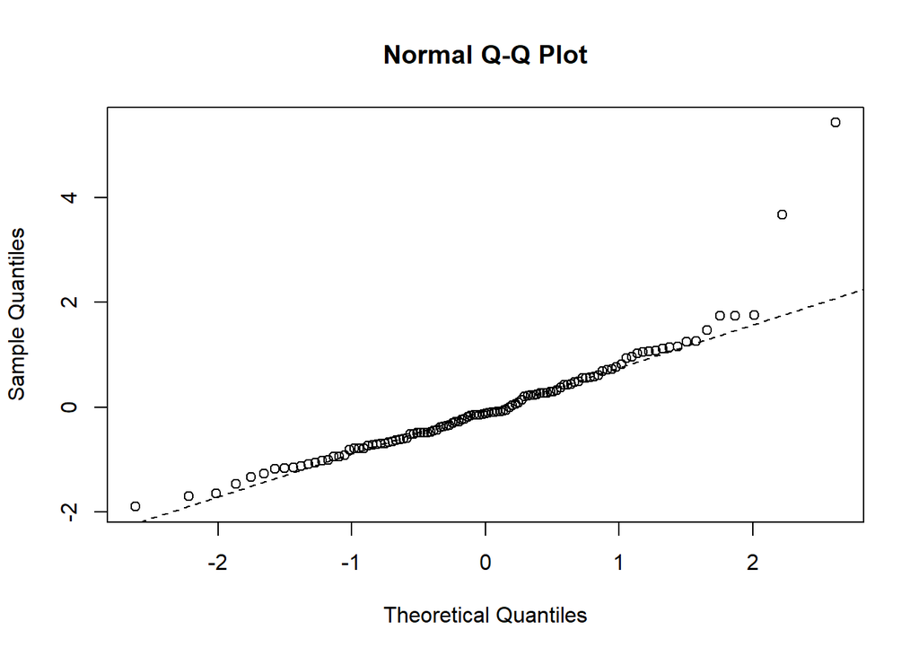

```r
# Grafico de probabilidade (ou de quantis) para os resíduos padronizados
resid.std <- (resid(rlm.m2))/sd(resid(rlm.m2))
qqnorm(resid.std)
qqline(resid.std, lty="dashed") # adiciona reta que passa pelo 1o. e 3o. quartis
```

O gráfico de quantis não indica desvios importantes da normalidade, porém apresenta apenas 2 possíveis outliers. Neste caso, não faz sentido gerar graficos temporais, já que os dados foram obtidos em “cross-section”.

#### 4.

```r
rm(list=ls())
scenic <- read.table("data/SCENIC.txt", header = FALSE)
```

```r
rm(list = ls())


scenic <- read.table("data/SCENIC.txt")
colnames(scenic) <- c("IDnumber","LengthStay","Age","InfectRisk","CultRatio","XrayRatio","NBeds","MedSchool","Region","DailyCensus","NNurses","Facilities")

attach(scenic)
data_region <- data.frame(Age = Age, CultRatio = CultRatio, DailyCensus = DailyCensus, Facilities = Facilities, Region = Region, InfectRisk = InfectRisk)
attach(data_region)
```

##### Região 1:

```r
data_region1 <- subset(data_region, Region == 1)

rlm.m1 <- lm(InfectRisk ~  Age + CultRatio + DailyCensus + Facilities, data = data_region1)
rlm.m1
```

```
##
## Call:
## lm(formula = InfectRisk ~ Age + CultRatio + DailyCensus + Facilities,
##     data = data_region1)
##
## Coefficients:
## (Intercept)          Age    CultRatio  DailyCensus   Facilities
##   -3.349576     0.116954     0.058240     0.001508     0.006613
```

```r
summary(rlm.m1)
```

```
##
## Call:
## lm(formula = InfectRisk ~ Age + CultRatio + DailyCensus + Facilities,
##     data = data_region1)
##
## Residuals:
##      Min       1Q   Median       3Q      Max
## -2.67221 -0.62955  0.05195  0.72448  1.54486
##
## Coefficients:
##              Estimate Std. Error t value Pr(>|t|)
## (Intercept) -3.349576   2.709974  -1.236   0.2289
## Age          0.116954   0.050215   2.329   0.0290 *
## CultRatio    0.058240   0.022609   2.576   0.0169 *
## DailyCensus  0.001508   0.001651   0.913   0.3706
## Facilities   0.006613   0.023041   0.287   0.7767
## ---
## Signif. codes:  0 '***' 0.001 '**' 0.01 '*' 0.05 '.' 0.1 ' ' 1
##
## Residual standard error: 1.011 on 23 degrees of freedom
## Multiple R-squared:  0.4613, Adjusted R-squared:  0.3676
## F-statistic: 4.924 on 4 and 23 DF,  p-value: 0.005128
```

Aqui, para a região 1, a var. dependente é InfectRisk e as var.explicativas são Age, CultRatio, DailyCensus, Facilities. Neste modelo não admitimos interações entre as var. ou termos de ordem superior.

Assim, o modelo pode ser descrito pela equação:

Yhat = -3.349576 + 0.116954 * Age + 0.058240 * CultRatio + 0.001508 * DailyCensus + 0.006613 * Facilities (eq.plano)

##### Região 2:

```r
data_region2 <- subset(data_region, Region == 2)

rlm.m2 <- lm(InfectRisk ~  Age + CultRatio + DailyCensus + Facilities, data = data_region2)
rlm.m2
```

```
##
## Call:
## lm(formula = InfectRisk ~ Age + CultRatio + DailyCensus + Facilities,
##     data = data_region2)
##
## Coefficients:
## (Intercept)          Age    CultRatio  DailyCensus   Facilities
##    2.291536     0.004742     0.058030     0.001172     0.015018
```

```r
summary(rlm.m2)
```

```
##
## Call:
## lm(formula = InfectRisk ~ Age + CultRatio + DailyCensus + Facilities,
##     data = data_region2)
##
## Residuals:
##      Min       1Q   Median       3Q      Max
## -1.98794 -0.70073  0.09807  0.59809  2.07417
##
## Coefficients:
##             Estimate Std. Error t value Pr(>|t|)
## (Intercept) 2.291536   2.686553   0.853  0.40118
## Age         0.004742   0.047213   0.100  0.92074
## CultRatio   0.058030   0.016192   3.584  0.00132 **
## DailyCensus 0.001172   0.002094   0.560  0.58016
## Facilities  0.015018   0.021510   0.698  0.49104
## ---
## Signif. codes:  0 '***' 0.001 '**' 0.01 '*' 0.05 '.' 0.1 ' ' 1
##
## Residual standard error: 1.101 on 27 degrees of freedom
## Multiple R-squared:  0.4115, Adjusted R-squared:  0.3243
## F-statistic: 4.719 on 4 and 27 DF,  p-value: 0.005111
```

Aqui, para a região 2, a var. dependente é InfectRisk e as var.explicativas são Age, CultRatio, DailyCensus, Facilities. Neste modelo não admitimos interações entre as var. ou termos de ordem superior.

Assim, o modelo pode ser descrito pela equação:

Yhat = 2.291536 + 0.004742 * Age + 0.058030 * CultRatio + 0.001172 * DailyCensus + 0.015018 * Facilities (eq.plano)

##### Região 3:

```r
data_region3 <- subset(data_region, Region == 3)

rlm.m3 <- lm(InfectRisk ~  Age + CultRatio + DailyCensus + Facilities, data = data_region3)
rlm.m3
```

```
##
## Call:
## lm(formula = InfectRisk ~ Age + CultRatio + DailyCensus + Facilities,
##     data = data_region3)
##
## Coefficients:
## (Intercept)          Age    CultRatio  DailyCensus   Facilities
##   -0.143858     0.030848     0.102281     0.004114     0.008039
```

```r
summary(rlm.m3)
```

```
##
## Call:
## lm(formula = InfectRisk ~ Age + CultRatio + DailyCensus + Facilities,
##     data = data_region3)
##
## Residuals:
##     Min      1Q  Median      3Q     Max
## -1.9122 -0.4960  0.1105  0.4411  2.3904
##
## Coefficients:
##              Estimate Std. Error t value Pr(>|t|)
## (Intercept) -0.143858   2.323190  -0.062   0.9510
## Age          0.030848   0.039175   0.787   0.4368
## CultRatio    0.102281   0.021215   4.821 3.34e-05 ***
## DailyCensus  0.004114   0.002160   1.905   0.0658 .
## Facilities   0.008039   0.020362   0.395   0.6956
## ---
## Signif. codes:  0 '***' 0.001 '**' 0.01 '*' 0.05 '.' 0.1 ' ' 1
##
## Residual standard error: 0.9678 on 32 degrees of freedom
## Multiple R-squared:  0.6088, Adjusted R-squared:   0.56
## F-statistic: 12.45 on 4 and 32 DF,  p-value: 3.225e-06
```

Aqui, para a região 3, a var. dependente é InfectRisk e as var.explicativas são Age, CultRatio, DailyCensus, Facilities. Neste modelo não admitimos interações entre as var. ou termos de ordem superior.

Assim, o modelo pode ser descrito pela equação:

Yhat = -0.143858 + 0.030848 * Age + 0.102281 * CultRatio + 0.004114 * DailyCensus + 0.008039 * Facilities (eq.plano)

##### Região 4:

```r
data_region4 <- subset(data_region, Region == 4)

rlm.m4 <- lm(InfectRisk ~  Age + CultRatio + DailyCensus + Facilities, data = data_region4)
rlm.m4
```

```
##
## Call:
## lm(formula = InfectRisk ~ Age + CultRatio + DailyCensus + Facilities,
##     data = data_region4)
##
## Coefficients:
## (Intercept)          Age    CultRatio  DailyCensus   Facilities
##    1.566549     0.035241     0.040328    -0.000664     0.012792
```

```r
summary(rlm.m4)
```

```
##
## Call:
## lm(formula = InfectRisk ~ Age + CultRatio + DailyCensus + Facilities,
##     data = data_region4)
##
## Residuals:
##      Min       1Q   Median       3Q      Max
## -1.69113 -0.42384 -0.01758  0.77365  1.11734
##
## Coefficients:
##              Estimate Std. Error t value Pr(>|t|)
## (Intercept)  1.566549   4.382848   0.357    0.728
## Age          0.035241   0.074383   0.474    0.645
## CultRatio    0.040328   0.058780   0.686    0.507
## DailyCensus -0.000664   0.003173  -0.209    0.838
## Facilities   0.012792   0.025866   0.495    0.631
##
## Residual standard error: 0.9766 on 11 degrees of freedom
## Multiple R-squared:  0.0896, Adjusted R-squared:  -0.2415
## F-statistic: 0.2706 on 4 and 11 DF,  p-value: 0.8908
```

Aqui, para a região 4, a var. dependente é InfectRisk e as var.explicativas são Age, CultRatio, DailyCensus, Facilities. Neste modelo não admitimos interações entre as var. ou termos de ordem superior.

Assim, o modelo pode ser descrito pela equação:

Yhat = 1.566549 + 0.035241 * Age + 0.040328 * CultRatio - 0.000664 * DailyCensus + 0.012792 * Facilities (eq.plano)

Analisando os coeficientes para cada variável, podemos analisar a dependência de cada variável explicativa em cada modelo.

Para a variável explicativa Age, percebe-se que temos um coeficiente maior para Região 1, implicando, assim, numa maior influência desse coeficiente na variável de resposta. Em contrapartida, na Região 2, tal coeficiente é menor, implicando numa menor influência. Já para as regiões 3 e 4, os coeficientes estão intermediários.

Para a variável explicativa CultRatio, temos um coeficiente maior para a Região 3, ou seja, implicando numa maior influência de tal coeficiente na variável de resposta da região em questão. Para as outras regiões, o coefiente é semelhante.

Para a variável explicativa DailyCensus, assim como em CultRatio, temos um coeficiente maior para a Região 3. E menor na região 4. Analisando os coeficientes dessa variável para todas as regiões, pode-se notar que são menores que os coeficientes de outras variáveis, indicando uma baixa influência dessa variável explicativa para a variável de resposta para todas as regiões analisadas.

Para a variável explicativa Facilities, temos um maior coeficiente para as regiões 2 e 4, e uma menor influência de tal coeficiente na variável de resposta para a região 1.

### Análise do MSE e Raj²

#### Região 1

MSE = 1.022, Raj-squared = 0.3676

#### Região 2

MSE = 1.212, Raj-squared = 0.3243

#### Região 3

MSE = 0.937, Raj-squared = 0.56

#### Região 4

MSE = 0.954, Raj-squared = -0.2415

O valor de MSE da região 2 foi a maior e o da região 3 e 4 foram os menores. Quanto menor o valor de MSE, melhor a qualidade do estimador e melhor a aproximação do modelo com o valor real.

O valor de Raj-squared da região 4 é negativo e é o menor das regiões, enquanto que o da região 3 é a maior. Quanto maior o valor de Raj-squared, melhor é explicado o modelo pelas variáveis explicativas, indicando que o melhor modelo é a região 3. Por outro lado, a região 4 possui variáveis explicativas insignificantes, o que poderia ser corrigido aumentando a amostragem.

Apesar do MSE baixo da região 4, indicando uma boa aproximação do modelo aos dados obtidos, o valor de Raj-squared indica que a variável de resposta, para essa região, não é bem explicada para o conjunto de variáveis explicativas. E dessa forma, podemos concluir que não basta analisar apenas um fator isoladamente, como MSE, para poder tirar conclusões.

Por outro lado, o valor baixo do MSE e o valor alto de Raj-squared na região 3 indica que o modelo é bem explicado pelas variáveis explicativas.

### Análise de Somas de Quadrados Extras

```r
#incialmente criamos um modelo com as duas variáveis (Age e Infect Risk)
data <- data.frame(LengthStay = LengthStay, CultRatio = CultRatio, DailyCensus = DailyCensus, Facilities = Facilities, NNurses = NNurses, InfectRisk = InfectRisk, Age = Age)
attach(data)
lm_original <- lm(LengthStay ~  Age + InfectRisk)
anova(lm_original)
```

|  | Df | Sum Sq | Mean Sq | F value | Pr(>F) |
| --- | --- | --- | --- | --- | --- |
| Age | 1 | 14.6041 | 14.604100 | 5.77340 | 1.794427e-02 |
| InfectRisk | 1 | 116.3559 | 116.355852 | 45.99865 | 6.188208e-10 |
| Residuals | 110 | 278.2504 | 2.529549 | NA | NA |

```r
#Serão criados 4 modelos além do inicial, de modo a incluir cada uma das novas variáveis, bem como um teste anova para cada modelo, de  modo a comparar os coeficientes obtidos.
lm_cultratio <- lm(LengthStay ~  Age + InfectRisk + CultRatio, data = data)
anova(lm_cultratio)
```

|  | Df | Sum Sq | Mean Sq | F value | Pr(>F) |
| --- | --- | --- | --- | --- | --- |
| Age | 1 | 14.604100 | 14.604100 | 5.788483 | 1.781433e-02 |
| InfectRisk | 1 | 116.355852 | 116.355852 | 46.118821 | 6.100213e-10 |
| CultRatio | 1 | 3.247997 | 3.247997 | 1.287377 | 2.590210e-01 |
| Residuals | 109 | 275.002432 | 2.522958 | NA | NA |

```r
lm_dailycensus <- lm(LengthStay ~  Age + InfectRisk + DailyCensus, data = data)
anova(lm_dailycensus)
```

|  | Df | Sum Sq | Mean Sq | F value | Pr(>F) |
| --- | --- | --- | --- | --- | --- |
| Age | 1 | 14.60410 | 14.604100 | 6.622987 | 1.141016e-02 |
| InfectRisk | 1 | 116.35585 | 116.355852 | 52.767603 | 5.927950e-11 |
| DailyCensus | 1 | 37.89864 | 37.898637 | 17.187105 | 6.722471e-05 |
| Residuals | 109 | 240.35179 | 2.205062 | NA | NA |

```r
lm_nnurses <- lm(LengthStay ~  Age + InfectRisk + NNurses, data = data)
anova(lm_nnurses)
```

|  | Df | Sum Sq | Mean Sq | F value | Pr(>F) |
| --- | --- | --- | --- | --- | --- |
| Age | 1 | 14.6041 | 14.604100 | 5.942982 | 1.639264e-02 |
| InfectRisk | 1 | 116.3559 | 116.355852 | 47.349767 | 3.930753e-10 |
| NNurses | 1 | 10.3972 | 10.397202 | 4.231030 | 4.207858e-02 |
| Residuals | 109 | 267.8532 | 2.457369 | NA | NA |

```r
lm_facilities <- lm(LengthStay ~  Age + InfectRisk + Facilities, data = data)
anova(lm_facilities)
```

|  | Df | Sum Sq | Mean Sq | F value | Pr(>F) |
| --- | --- | --- | --- | --- | --- |
| Age | 1 | 14.6041 | 14.604100 | 5.936953 | 1.644583e-02 |
| InfectRisk | 1 | 116.3559 | 116.355852 | 47.301732 | 3.998472e-10 |
| Facilities | 1 | 10.1252 | 10.125197 | 4.116160 | 4.491281e-02 |
| Residuals | 109 | 268.1252 | 2.459865 | NA | NA |

Do teste ANOVA temos que os SSE para cada uma das variáveis incluídas são: SSEcultratio = 3.247997; SSEdailycensus = 37.89864; SSEnnurses = 10.3972; SSEfacilities = 10.1252; Dessa maneira, a variável explicativa que constitui a melhor inclusão é a que tem maior SSE, uma vez que isso indica que um maior percentual dos dados é explicado com a inclusão da nova variável. Para os modelos tratados têm-se então que a melhor inclusão é a de DailyCensus.

### Discussão da estatística F parcial para os modelos

Inicialmente podemos notar que os valores F obtidos para as variáveis originais (Age e Infect Risk) sofrem leves alterações para cada um dos 4 modelos, isso se deve ao fato de essa estatística ser uma razão dos valores de MSR para as variáveis originais e MSE para todas as variáveis incluíndo a nova. Como a variável nova é diferente em cada modelo, o denominador se altera e a estatística F muda.

Em seguida, tem-se os valores de F para cada um dos 4 modelos novos: Fcultratio = 1.287377; Fdailycensus = 17.187105; Fnnurses = 4.231030; Ffacilities = 4.116160;

Para essa estatística, tem-se que valores elevados levam à rejeição da hipótese nula (coeficiente da variável nula). O valor obtido para a variável DailyCensus indica que sua adição é relevante ao modelo, melhorando o ajuste. Isso é confirmado pelo p-valor encontrado no teste ANOVA: p = 6.722471e-05. Dessa forma, há uma chance muito baixa de que essa estatística tenha sido obtida por acaso, sendo válido aceitar esse risco para o caso dessa variável.

Por outro lado, a variável CultRatio apresentou o menor valor de F, bem como um valor p maior que 5%. Disso concluímos que a contribuição dessa variável pode ser rejeitada do modelo, uma vez que a hipótese nula foi aceita. As outras duas variáveis apresentam estatísticas F intermediárias à essas duas previamente discutidas, e os p-valores obtidos levam à inclusão delas no modelo. Assim conclui-se que estas são relevantes, porém com contribuição menor do que DailyCensus.

### Multicolinearidade

Um modelo de regressão de 1a. ordem para `LengthStay` em função de `Age`, `XrayRatio`, `DailyCensus` é construído com base nas observações 57-113. Com base na matriz de gráficos de dispersão, matriz de correlação e VIFs, analise se há indícios de problemas sérios de multicolinearidade. Justifique sua análise.

Construindo uma nova base de dados com os pontos desejados:

```r
newdata <- data.frame(LengthStay = LengthStay, DailyCensus = DailyCensus, Age = Age, XrayRatio = XrayRatio)
newdata <- newdata[-c(1:56), ]
attach(newdata)
```

Criação do modelo linear desejado:

```r
lm_multicolinear <- lm(LengthStay ~  Age + XrayRatio + DailyCensus, data = newdata)
```

Para a discussão de multicolinearidade do modelo, serão feitas análises de gráficos de dispersão, da matriz de correlação do modelo e VIF do modelo.

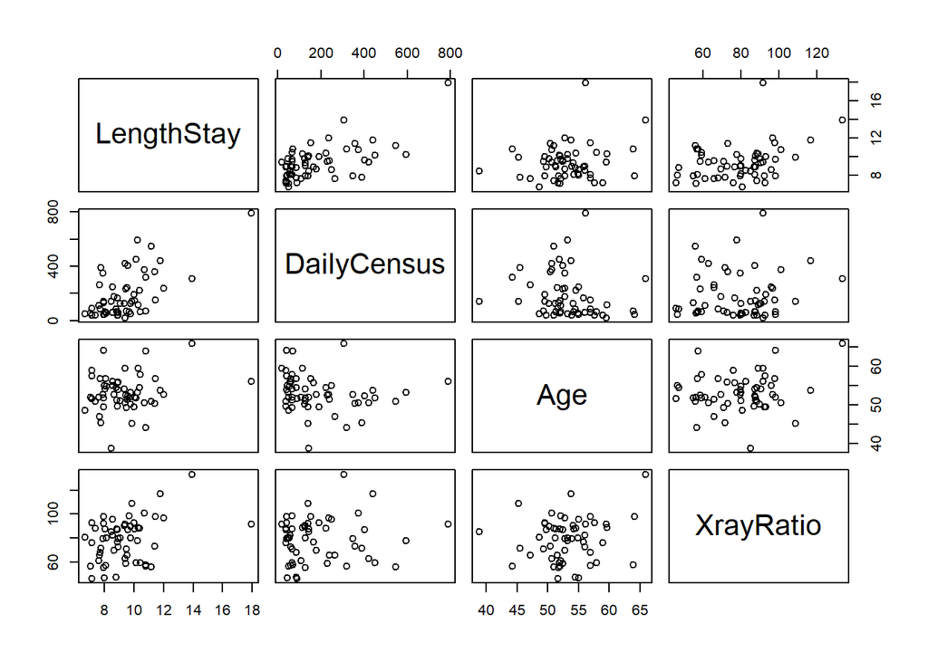

```r
plot(newdata)
```

```r
library(corrplot)
cor(newdata)
```

```
##             LengthStay DailyCensus        Age  XrayRatio
## LengthStay   1.0000000  0.63458724  0.1896219 0.36393576
## DailyCensus  0.6345872  1.00000000 -0.1722121 0.08554147
## Age          0.1896219 -0.17221214  1.0000000 0.16098871
## XrayRatio    0.3639358  0.08554147  0.1609887 1.00000000
```

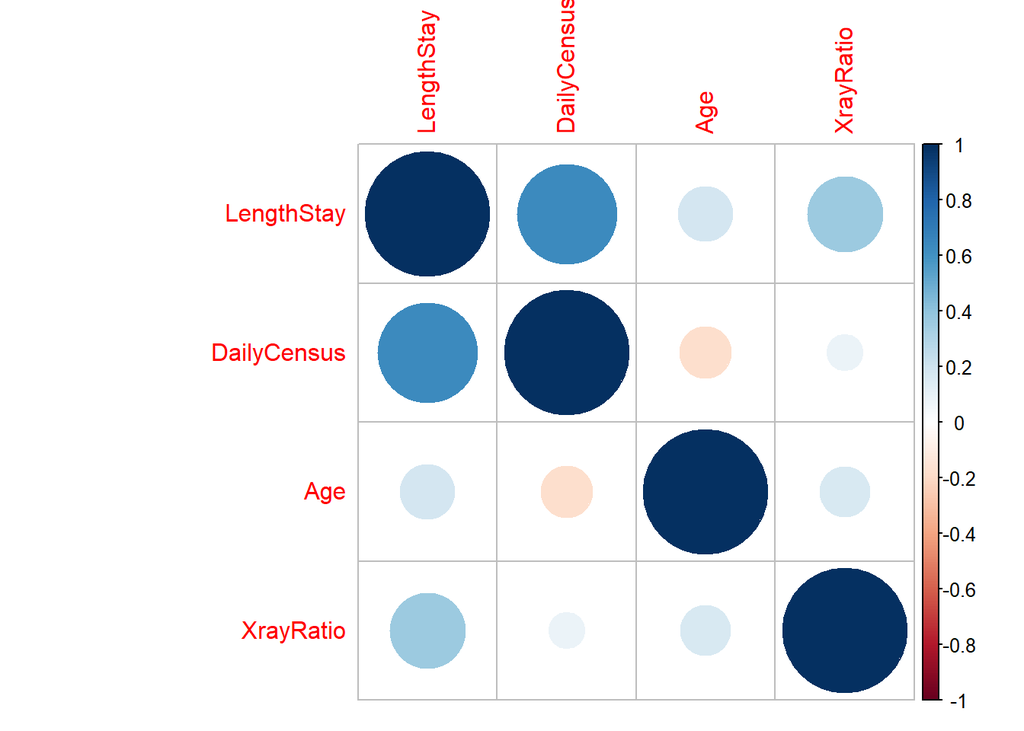

```r
corrplot(cor(newdata), method = "circle", order = "hclust", sig.level = 0.01, insig = "blank")
```

```r
library(car)
vif(lm_multicolinear)
```

```
##         Age   XrayRatio DailyCensus
##    1.064693    1.040733    1.044744
```

Uma observação inicial dos gráficos de dispersão obtidos sugere que não há aparente relação linear entre as variáveis explicativas Age, XrayRatio e Daily Census. Em seguida, a matriz de correlação corrobora essa hipótese, uma vez que não apresentou nenhum valor próximo de 1 (o valor que mais se afasta de foi -0.1722121 para Age versus DailyCensus). Em seguida, fez-se o VIF para o modelo criado. Para esse teste, temos que valores acima de 5 indicam sérios efeitos de multicolinearidade, sendo que o coeficiente de regressão para a variável não está sendo estimado de maneira apropriada. Para o modelo obtido foram encontrados valores próximos de 1, indicando que não há aumento relevante da variância dos coeficientes da regressão devido à presença de multicolinearidade. Dessa maneira, os três resultados obtidos indicam que não há efeitos sérios de multicolinearidade presentes no modelo construido.